# Fordgobike Data Exploration

## Preliminary Wrangling

> This data set includes information about individual rides made in a bike-sharing system covering the greater San Francisco Bay area.

```python
# import all packages and set plots to be embedded inline
import numpy as np
import pandas as pd
import matplotlib.pyplot as plt
import seaborn as sb
import time
import calendar

%matplotlib inline
```

```python
# load in the dataset into a pandas dataframe, print statistics
df= pd.read_csv('201902-fordgobike-tripdata.csv')
```

```python
print(df.shape)
print(df.dtypes)
print(df.head())
```

```
(183412, 16)
duration_sec                 int64
start_time                  object
end_time                    object
start_station_id           float64
start_station_name          object
start_station_latitude     float64
start_station_longitude    float64
end_station_id             float64
end_station_name            object
end_station_latitude       float64
end_station_longitude      float64
bike_id                      int64
user_type                   object
member_birth_year          float64
member_gender               object
bike_share_for_all_trip     object
dtype: object
   duration_sec                start_time                  end_time  \
0         52185  2019-02-28 17:32:10.1450  2019-03-01 08:01:55.9750
1         42521  2019-02-28 18:53:21.7890  2019-03-01 06:42:03.0560
2         61854  2019-02-28 12:13:13.2180  2019-03-01 05:24:08.1460
3         36490  2019-02-28 17:54:26.0100  2019-03-01 04:02:36.8420
4          1585  2019-02-28 23:54:18.5490  2019-03-01 00:20:44.0740

   start_station_id                                start_station_name  \
0              21.0  Montgomery St BART Station (Market St at 2nd St)
1              23.0                     The Embarcadero at Steuart St
2              86.0                           Market St at Dolores St
3             375.0                           Grove St at Masonic Ave
4               7.0                               Frank H Ogawa Plaza

   start_station_latitude  start_station_longitude  end_station_id  \
0               37.789625              -122.400811            13.0
1               37.791464              -122.391034            81.0
2               37.769305              -122.426826             3.0
3               37.774836              -122.446546            70.0
4               37.804562              -122.271738           222.0

                               end_station_name  end_station_latitude  \
0                Commercial St at Montgomery St             37.794231
1                            Berry St at 4th St             37.775880
2  Powell St BART Station (Market St at 4th St)             37.786375
3                        Central Ave at Fell St             37.773311
4                         10th Ave at E 15th St             37.792714

   end_station_longitude  bike_id   user_type  member_birth_year  \
0            -122.402923     4902    Customer             1984.0
1            -122.393170     2535    Customer                NaN
2            -122.404904     5905    Customer             1972.0
3            -122.444293     6638  Subscriber             1989.0
4            -122.248780     4898  Subscriber             1974.0

  member_gender bike_share_for_all_trip
0          Male                      No
1           NaN                      No
2          Male                      No
3         Other                      No
4          Male                     Yes
```

```python
df.isna().sum()
```

[output not shown]

```python
#Change start_time columns to datetime data type and break those columns into: time of the day, day of the week, month of the year, year
df['start_time']= pd.to_datetime(df['start_time'])
df['start_year']= df['start_time'].dt.year


df['start_month']= df['start_time'].dt.month
df['start_month']= df['start_month'].apply(lambda x: calendar.month_abbr[x])
```

```python
#make weekday column
df['start_day']= df['start_time'].dt.weekday
df['start_day']= df['start_day'].map({0:'Mon',1:'Tue',2:'Wed',3:'Thu',4:'Fri',5:'Sat',6:'Sun'})
```

```python
# make hour columnn and divide into three group: morning, afternoon, evening
df['start_hour']= df['start_time'].dt.hour

bin_edges = [0 ,6, 12, 18, 23]
bin_names = ['Night', 'Morning','Afternoon', 'Evening']
df['period_of_day'] = pd.cut(df['start_hour'],bin_edges, labels = bin_names)
```

```python
df.period_of_day.fillna('Night', inplace=True)
```

```python
#Change id columns to str type
df['start_station_id']= df['start_station_id'].astype('str')
df['end_station_id']= df['end_station_id'].astype('str')
df['bike_id']= df['bike_id'].astype('str')
```

```python
#Change user_type, member_gender to category type
df['user_type']= df['user_type'].astype('category')
df['member_gender']= df['member_gender'].astype('category')
```

```python
#Delete unnecessary columns such as longtitude, latitude and bike_share_for_all_trip
df= df.drop('start_station_latitude', axis = 1)
df= df.drop('start_station_longitude', axis = 1)
df= df.drop('end_station_latitude', axis = 1)
df= df.drop('end_station_longitude', axis = 1)
df= df.drop('bike_share_for_all_trip', axis = 1)
```

```python
#Make age column based on member_birth_year
df['age']= df['member_birth_year'].apply(lambda x: 2020-x)
```

```python
#Change duration from second to minute
df['duration_min']= df['duration_sec'].apply(lambda x: x/60)
df['duration_min']= df['duration_min'].astype('int')
```

```python
df = df[['duration_sec','duration_min', 'start_time','start_year','start_month','start_day','start_hour', 'period_of_day','end_time','start_station_id','start_station_name','end_station_id','end_station_name','bike_id','user_type','member_birth_year','age','member_gender' ]]
```

```python
# convert start_day, and period_of_day into ordered categorical types
ordinal_var_dict = {'start_day': ['Mon', 'Tue', 'Wed', 'Thu', 'Fri', 'Sat', 'Sun'], 'period_of_day': ['Morning', 'Afternoon','Evening','Night']}

for var in ordinal_var_dict:
    ordered_var = pd.api.types.CategoricalDtype(ordered = True, categories = ordinal_var_dict[var])
    df[var] = df[var].astype(ordered_var)
```

```python
df.head()
```

|  | duration_sec | duration_min | start_time | start_year | start_month | start_day | start_hour | period_of_day | end_time | start_station_id | start_station_name | end_station_id | end_station_name | bike_id | user_type | member_birth_year | age | member_gender |
| --- | --- | --- | --- | --- | --- | --- | --- | --- | --- | --- | --- | --- | --- | --- | --- | --- | --- | --- |
| 0 | 52185 | 869 | 2019-02-28 17:32:10.145 | 2019 | Feb | Thu | 17 | Afternoon | 2019-03-01 08:01:55.9750 | 21.0 | Montgomery St BART Station (Market St at 2nd St) | 13.0 | Commercial St at Montgomery St | 4902 | Customer | 1984.0 | 36.0 | Male |
| 1 | 42521 | 708 | 2019-02-28 18:53:21.789 | 2019 | Feb | Thu | 18 | Afternoon | 2019-03-01 06:42:03.0560 | 23.0 | The Embarcadero at Steuart St | 81.0 | Berry St at 4th St | 2535 | Customer | NaN | NaN | NaN |
| 2 | 61854 | 1030 | 2019-02-28 12:13:13.218 | 2019 | Feb | Thu | 12 | Morning | 2019-03-01 05:24:08.1460 | 86.0 | Market St at Dolores St | 3.0 | Powell St BART Station (Market St at 4th St) | 5905 | Customer | 1972.0 | 48.0 | Male |
| 3 | 36490 | 608 | 2019-02-28 17:54:26.010 | 2019 | Feb | Thu | 17 | Afternoon | 2019-03-01 04:02:36.8420 | 375.0 | Grove St at Masonic Ave | 70.0 | Central Ave at Fell St | 6638 | Subscriber | 1989.0 | 31.0 | Other |
| 4 | 1585 | 26 | 2019-02-28 23:54:18.549 | 2019 | Feb | Thu | 23 | Evening | 2019-03-01 00:20:44.0740 | 7.0 | Frank H Ogawa Plaza | 222.0 | 10th Ave at E 15th St | 4898 | Subscriber | 1974.0 | 46.0 | Male |

```python
df.info()
```

```
<class 'pandas.core.frame.DataFrame'>
RangeIndex: 183412 entries, 0 to 183411
Data columns (total 18 columns):
 #   Column              Non-Null Count   Dtype
---  ------              --------------   -----
 0   duration_sec        183412 non-null  int64
 1   duration_min        183412 non-null  int64
 2   start_time          183412 non-null  datetime64[ns]
 3   start_year          183412 non-null  int64
 4   start_month         183412 non-null  object
 5   start_day           183412 non-null  category
 6   start_hour          183412 non-null  int64
 7   period_of_day       183412 non-null  category
 8   end_time            183412 non-null  object
 9   start_station_id    183412 non-null  object
 10  start_station_name  183215 non-null  object
 11  end_station_id      183412 non-null  object
 12  end_station_name    183215 non-null  object
 13  bike_id             183412 non-null  object
 14  user_type           183412 non-null  category
 15  member_birth_year   175147 non-null  float64
 16  age                 175147 non-null  float64
 17  member_gender       175147 non-null  category
dtypes: category(4), datetime64[ns](1), float64(2), int64(4), object(7)
memory usage: 20.3+ MB
```

### What is the structure of your dataset?

> User types: Customer, Subcriber

> Period of day: Morning, Afternoon, Evening, Night

> Day: Monday to Sunday.

### What is/are the main feature(s) of interest in your dataset?

> I'm most interested in figuring out what features are best for predicting the duration of the trip in the dataset. Here are questions that I need to answer:

> . What is the average trip duration ?

> . How does the trip duration change as regards to age, user type, gender, period of day, day.

### What features in the dataset do you think will help support your investigation into your feature(s) of interest?

> Each element listed above affect somehow to the trip duration, but which one affects most is what I need to find out. At this point, I think age affect most to the duration as younger people tend to ride with longer time than older ones.

## Univariate Exploration

> I'll start by looking at the distribution of the main variable of interest: duration.

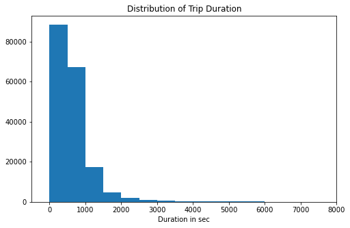

```python
# start with a standard-scaled plot
binsize = 500
bins = np.arange(0, df['duration_sec'].max()+binsize, binsize)

plt.figure(figsize=[8, 5])
plt.hist(data = df, x = 'duration_sec', bins = bins)
plt.xlabel('Duration in sec')
plt.xlim(-500, 8000)
plt.title('Distribution of Trip Duration')
```

> This distribution has a very long tail, so I will put a log scale to be easier to look at.

```python
df.duration_sec.describe()
```

[output not shown]

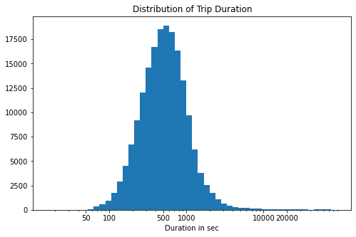

```python
# there's a long tail in the distribution, so let's put it on a log scale instead
log_binsize = 0.075
bins = 10 ** np.arange(1.2, np.log10(df['duration_sec'].max())+log_binsize, log_binsize)

plt.figure(figsize=[8, 5])
plt.hist(data = df, x = 'duration_sec', bins = bins)
plt.xscale('log')
plt.xticks([50,100,500, 1000,10000, 20000], [50,100,500,1000,10000,20000])
plt.xlabel('Duration in sec')
plt.title('Distribution of Trip Duration')
```

Next up, the first predictor variable of interest: age

```python
df.age.describe()
```

```
count    175147.000000
mean         35.193563
std          10.116689
min          19.000000
25%          28.000000
50%          33.000000
75%          40.000000
max         142.000000
Name: age, dtype: float64
```

```python
#drop people that are from 100 year olds
df= df.drop(df.query('age >= 100').index)
```

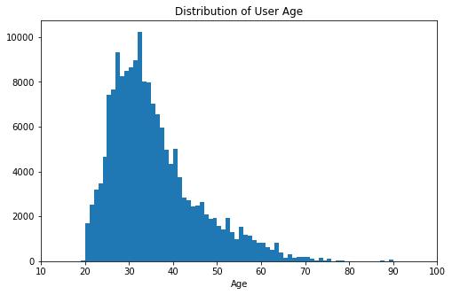

```python
# plotting age on a standard scale
binsize = 1
bins = np.arange(10, df['age'].max()+binsize, binsize)

plt.figure(figsize=[8, 5])
plt.hist(data = df, x = 'age', bins = bins)
plt.xlim([10,100])
plt.xlabel('Age')
plt.title('Distribution of User Age')
```

> The distribution is right-skewed with the peak is about 32 year olds. A large amount of people is between 25-35yo. The number of people decrease as age is higher. Few people with age more than 60yo.

```python
df.user_type.value_counts()
```

```
Subscriber    163474
Customer       19863
Name: user_type, dtype: int64
```

Now I move to another preditor: user type

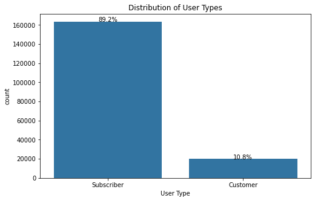

```python
# plot distribution of user type
plt.figure(figsize=[8, 5])
base_color = sb.color_palette()[0]

type_counts = df['user_type'].value_counts()

sb.countplot(data = df, x = 'user_type', color = base_color, order=type_counts.index)

locs, labels = plt.xticks()
n_users = sum(type_counts)

# print frequency on the bar chart
for loc, label in zip(locs, labels):
    count = type_counts[label.get_text()]
    pct_string = '{:0.1f}%'.format(100*count/n_users)

    plt.text(loc, count+8, pct_string, ha='center', color='black')

plt.title('Distribution of User Types')
plt.xlabel('User Type')
```

> In the dataset, 89.2% of users are subcribers, the remaining are casual customers.

About gender in the dataset

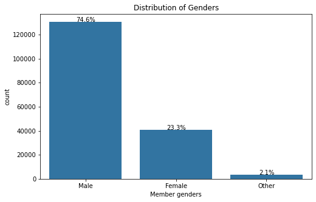

```python
# plot distribution of genders
plt.figure(figsize=[8, 5])
base_color = sb.color_palette()[0]

type_counts1 = df['member_gender'].value_counts()

sb.countplot(data = df, x = 'member_gender', color = base_color, order=type_counts1.index)

locs, labels = plt.xticks()
n_users1 = sum(type_counts1)

# print frequency on the bar chart
for loc, label in zip(locs, labels):
    count = type_counts1[label.get_text()]
    pct_string = '{:0.1f}%'.format(100*count/n_users1)

    plt.text(loc, count+8, pct_string, ha='center', color='black')

plt.title('Distribution of Genders')
plt.xlabel('Member genders')
```

> The majority of people in the dataset is male.

```python
df.start_day.value_counts()
```

```
Thu    35190
Tue    31796
Wed    29630
Fri    28963
Mon    26841
Sun    15515
Sat    15402
Name: start_day, dtype: int64
```

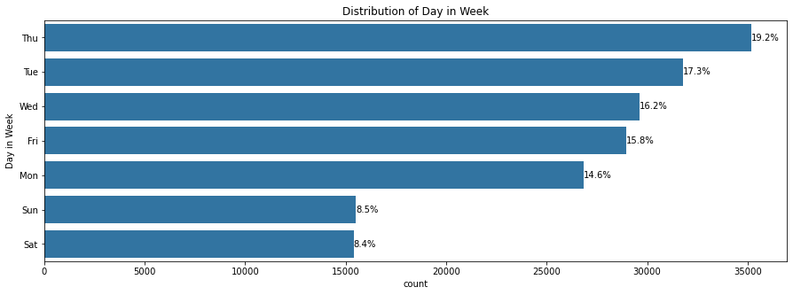

```python
plt.figure(figsize=[15, 5])
base_color = sb.color_palette()[0]

type_counts2 = df['start_day'].value_counts()
sb.countplot(data=df, y='start_day', color=base_color, order=type_counts2.index);


for i in range (type_counts2.shape[0]):
    count = type_counts2[i]
    # Convert count into a percentage, and then into string
    pct_string = '{:0.1f}%'.format(100*count/sum(type_counts2))
    plt.text(count+1, i, pct_string, va='center')

plt.title('Distribution of Day in Week')
plt.ylabel('Day in Week')
```

> People ride the most on Thursday and least on Saturday and Sunday.

Now I move to analyse: Period of day

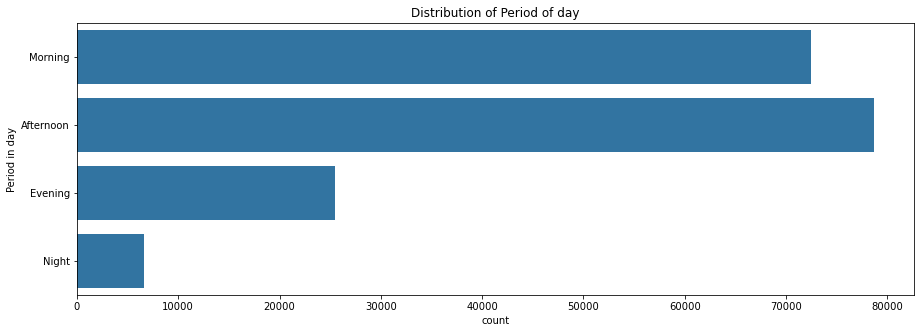

```python
level_order = ['Morning', 'Afternoon', 'Evening', 'Night']
ordered_day = pd.api.types.CategoricalDtype(ordered = True, categories=level_order)
df['period_of_day'] = df['period_of_day'].astype(ordered_day)

plt.figure(figsize=[15, 5])
base_color = sb.color_palette()[0]
sb.countplot(data=df, y='period_of_day', color=base_color)

plt.title('Distribution of Period of day')
plt.ylabel('Period in day')
```

People tend to ride most in the morning and afternoon.

### Discuss the distribution(s) of your variable(s) of interest. Were there any unusual points? Did you need to perform any transformations?

> The trip duration contain too many value and range is large. It is hard to see and understand the distribution so that I make a log tranformation for the x-axis. After changing, I can see that the peak of the dataset is about 600 seconds. There is no another peak after 600 seconds, the distribution is decreasing gradually from 600 seconds.

### Of the features you investigated, were there any unusual distributions? Did you perform any operations on the data to tidy, adjust, or change the form of the data? If so, why did you do this?

> I have tranformed some data columns such as birth year into age, time of day into period of day because it can give a better explaination of these data.

> I deleted data of people whose age >= 100 because it is not true data.

## Bivariate Exploration

Firstly, I explore the correllation between duration and age

```python
df1= df[['duration_sec','start_day','period_of_day','user_type','age',
       'member_gender']]
df1.head()
```

|  | duration_sec | start_day | period_of_day | user_type | age | member_gender |
| --- | --- | --- | --- | --- | --- | --- |
| 0 | 52185 | Thu | Afternoon | Customer | 36.0 | Male |
| 1 | 42521 | Thu | Afternoon | Customer | NaN | NaN |
| 2 | 61854 | Thu | Morning | Customer | 48.0 | Male |
| 3 | 36490 | Thu | Afternoon | Subscriber | 31.0 | Other |
| 4 | 1585 | Thu | Evening | Subscriber | 46.0 | Male |

```python
mean= df1.age.mean()
df1.age.fillna(mean, inplace = True)
```

```python
df1.age =df1.age.astype('int')
```

```python
numeric_vars = ['age','duration_sec']
categoric_vars = ['start_day','period_of_day','user_type','member_gender']
```

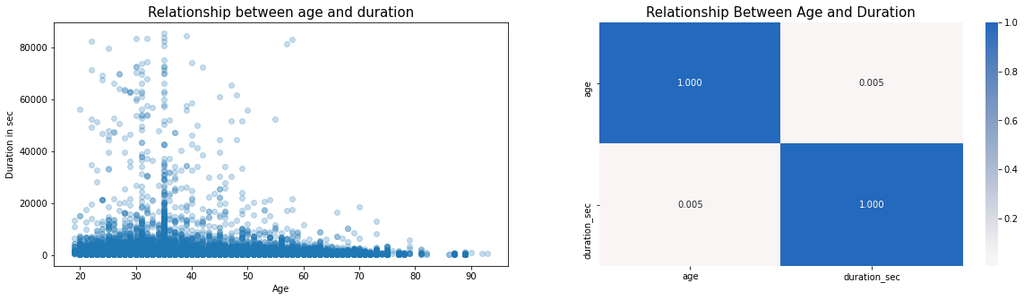

```python
plt.figure(figsize=[20,5])

plt.subplot(1, 2, 1)
plt.scatter(data = df1, x = 'age', y = 'duration_sec', alpha = 0.25);
plt.xlabel('Age')
plt.ylabel('Duration in sec')
plt.title('Relationship between age and duration', fontsize = 15)

plt.subplot(1, 2, 2)
sb.heatmap(df1[numeric_vars].corr(), annot = True, fmt = '.3f',
           cmap = 'vlag_r', center = 0)
plt.title('Relationship Between Age and Duration', fontsize = 15)
```

Let's move on to looking at how duration correlates with day of the week.

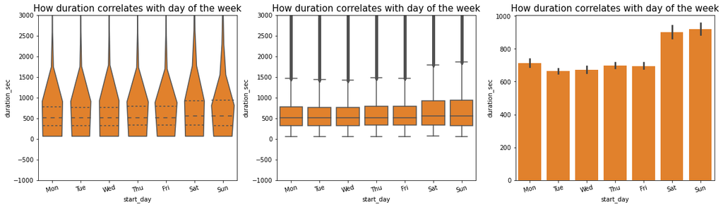

```python
plt.figure(figsize = [20, 5])
base_color = sb.color_palette()[1]

#violin plot
plt.subplot(1, 3, 1)
ax1 = sb.violinplot(data=df1, x='start_day', y='duration_sec', color=base_color, inner='quartile', cut = 0)
plt.xticks(rotation=15)
plt.ylim([-1000, 3000])
plt.title('How duration correlates with day of the week', fontsize = 15)

# box plot
plt.subplot(1, 3, 2)
sb.boxplot(data=df1, x='start_day', y='duration_sec', color=base_color)
plt.xticks(rotation=15);
plt.ylim(ax1.get_ylim())
plt.title('How duration correlates with day of the week', fontsize = 15)


plt.subplot(1, 3, 3)
sb.barplot(data=df1, x='start_day', y='duration_sec', color = base_color)
plt.xticks(rotation = 15)
plt.title('How duration correlates with day of the week', fontsize = 15)
```

> People ride with pretty same duration during weekdays. In weekends, people tend to ride with longer time.

Let's check how duration correlates with period_of_day

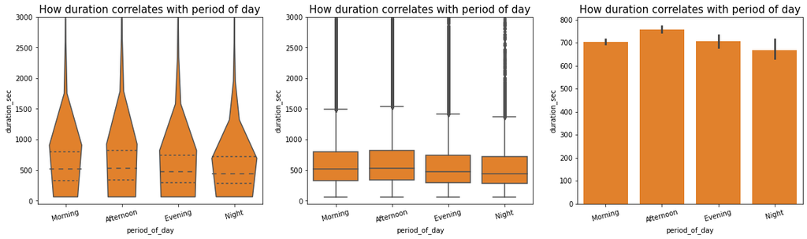

```python
plt.figure(figsize = [20, 5])
base_color = sb.color_palette()[1]

#violin plot
plt.subplot(1, 3, 1)
ax1 = sb.violinplot(data=df1, x='period_of_day', y='duration_sec', color=base_color, inner='quartile', cut = 0)
plt.xticks(rotation=15)
plt.ylim([-50, 3000])
plt.title('How duration correlates with period of day', fontsize = 15)

# box plot
plt.subplot(1, 3, 2)
sb.boxplot(data=df1, x='period_of_day', y='duration_sec', color=base_color)
plt.xticks(rotation=15);
plt.ylim(ax1.get_ylim())
plt.title('How duration correlates with period of day', fontsize = 15)


plt.subplot(1, 3, 3)
sb.barplot(data=df1, x='period_of_day', y='duration_sec', color = base_color)
plt.xticks(rotation = 15),
plt.title('How duration correlates with period of day', fontsize = 15)
```

> There is no apparent different in duration between period of day, trip duration does not seem to be affected by time of the day.

Let's check how duration correlates with user types

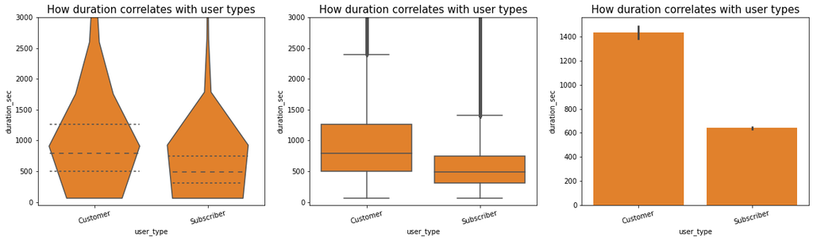

```python
plt.figure(figsize = [20, 5])
base_color = sb.color_palette()[1]

#violin plot
plt.subplot(1, 3, 1)
ax1 = sb.violinplot(data=df1, x='user_type', y='duration_sec', color=base_color, inner='quartile', cut = 0)
plt.xticks(rotation=15)
plt.ylim([-50, 3000])
plt.title('How duration correlates with user types', fontsize = 15)

# box plot
plt.subplot(1, 3, 2)
sb.boxplot(data=df1, x='user_type', y='duration_sec', color=base_color)
plt.xticks(rotation=15);
plt.ylim(ax1.get_ylim())
plt.title('How duration correlates with user types', fontsize = 15)


plt.subplot(1, 3, 3)
sb.barplot(data=df1, x='user_type', y='duration_sec', color = base_color)
plt.xticks(rotation = 15)
plt.title('How duration correlates with user types', fontsize = 15)
```

> Customers tend to ride with longer duration than subribers.

Let's check how duration correlates with member genders

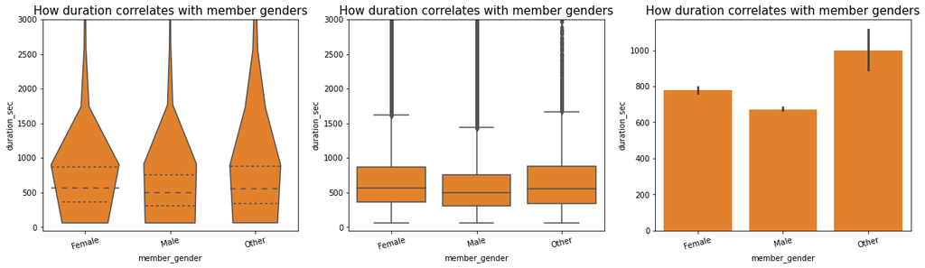

```python
plt.figure(figsize = [20, 5])
base_color = sb.color_palette()[1]

#violin plot
plt.subplot(1, 3, 1)
ax1 = sb.violinplot(data=df1, x='member_gender', y='duration_sec', color=base_color, inner='quartile', cut = 0)
plt.xticks(rotation=15)
plt.ylim([-50, 3000])
plt.title('How duration correlates with member genders', fontsize = 15)

# box plot
plt.subplot(1, 3, 2)
sb.boxplot(data=df1, x='member_gender', y='duration_sec', color=base_color)
plt.xticks(rotation=15);
plt.ylim(ax1.get_ylim())
plt.title('How duration correlates with member genders', fontsize = 15)


plt.subplot(1, 3, 3)
sb.barplot(data=df1, x='member_gender', y='duration_sec', color = base_color)
plt.xticks(rotation = 15)
plt.title('How duration correlates with member genders', fontsize = 15)
```

> Although number of male in the dataset is higher than number of female, female ride longer trip than male.

### Talk about some of the relationships you observed in this part of the investigation. How did the feature(s) of interest vary with other features in the dataset?

> Trip duration has a weak correlation with age. However, younger people tend to ride with longer time than older people. Duration is not affected much by days of the week. On weekends, the duration is a little bit higher than normal days because people have more time to enjoy the ride. For user type, customers ride longer than subribers as may be because customers pay lower fee for the service. There is no significant difference between the duration in different time of the day. About gender, trip duration is higher with female members

### Did you observe any interesting relationships between the other features (not the main feature(s) of interest)?

> At the beginning, I think Subribers ride more time than Customers because they are new to the system, so that they might want to try the service in the longer duration. However, the dataset shows the other way around.

> Furthermore, I expected man will have longer trip duration than female but according to the dataset, female takes longer trip.

## Multivariate Exploration

First I demonstrate the relationship between age and trip duration as regards to each user type

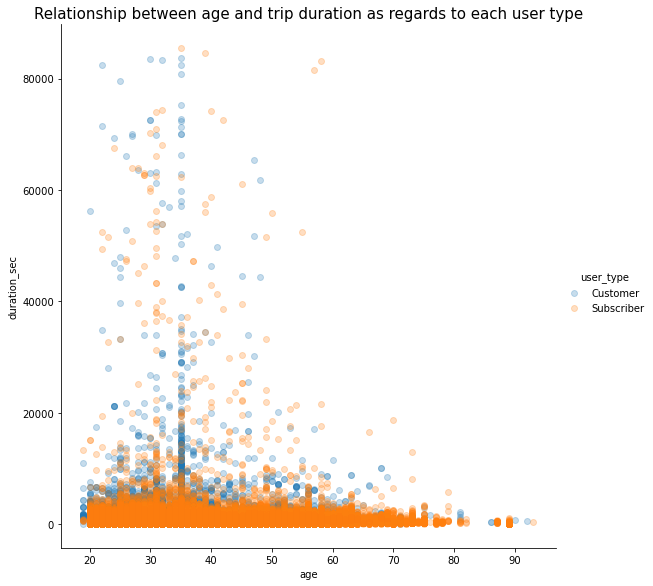

```python
g = sb.FacetGrid(data = df1, hue = 'user_type', size = 8)
g.map(plt.scatter, 'age', 'duration_sec', alpha=0.25)
g.add_legend()
plt.title('Relationship between age and trip duration as regards to each user type', fontsize=15)
```

> There is no significant difference between two user types as people who ride longer are younger people.

Now I demonstrate the relationship between age and trip duration as regards to each gender

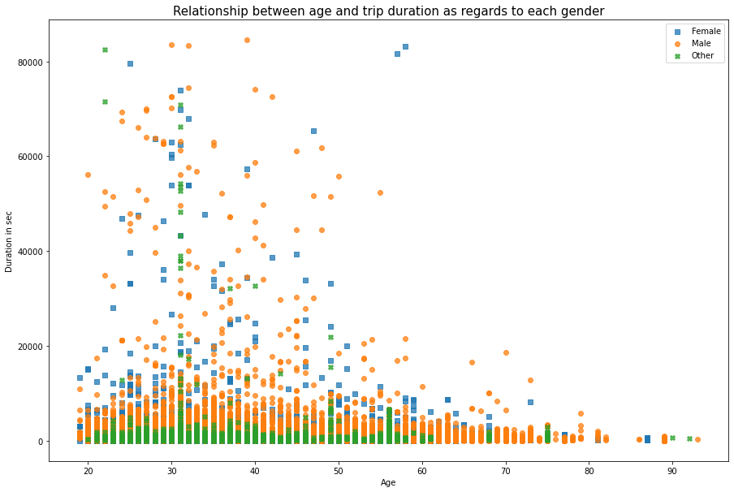

```python
markers = [['Female', 's'],['Male', 'o'], ['Other', 'X']]

plt.figure(figsize = [15, 10])
for x,y in markers:
    df1_type = df1[df1['member_gender'] == x]
    plt.scatter(df1_type['age'], df1_type['duration_sec'], marker=y, alpha=0.75)

plt.legend(['Female','Male','Other'])
plt.xlabel('Age')
plt.ylabel('Duration in sec')
plt.title('Relationship between age and trip duration as regards to each gender',fontsize=15)
```

> There is no significant difference between genders as people who ride longer are younger people. However, few females who aged around 55yo ride with very long duration.

I look at a little bit about age across genders and user types

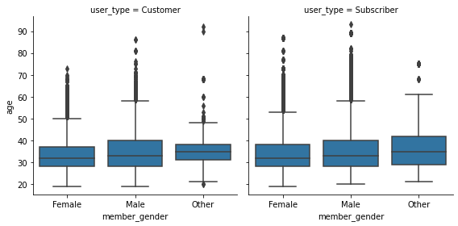

```python
a = sb.FacetGrid(data = df, col = 'user_type', size = 4)
a.map(sb.boxplot, 'member_gender', 'age')
```

> Age seem not to be different across genders and user types.

Lastly I look at trip duration across days and periods of day

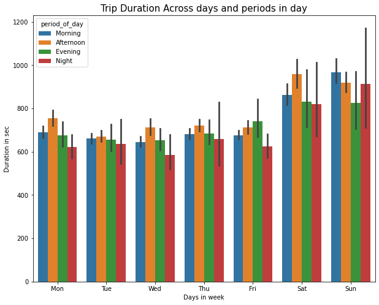

```python
plt.figure(figsize = [10, 8])

c = sb.barplot(x='start_day', y = 'duration_sec', hue='period_of_day', data=df1)
plt.title('Trip Duration Across days and periods in day', fontsize=15)
plt.xlabel('Days in week')
plt.ylabel('Duration in sec')
```